# Random Forest for Unbalanced Multiple Class Classification

```r
require(randomForest)
require(ggplot2)
require(reshape2) #melt fct
require(gridExtra) #grid arrange
require(RColorBrewer) #extend brewer palettes
require(colorRamps) #extend brewer palettes
require(colorspace) #hcl
```

## Introduction

Random Forest is a very powerful tool not only for classification but also regression. This notebook - a short version of my master thesis - will explain the imbalance problem and how to overcome it when working with Random Forest.

## The Imbalance Problem

So the great difficulties when dealing with unbalanced data are mainly that the forest will focus more on one group (the larger one) while the other group (the smaller one) will be neglected and that the overall error rate is not representative any longer.

There are many different ways to deal with the imbalance problem. It may be noted that balancing is not always meaningful since the prior probabilities are changed when the data is balanced. One way (amongst multiple others) to deal with unbalanced data is to use resampling methods. For each group the observations are resampled to build new groups of equal size.

Three different sampling methods are evaluated and compared based on the so-called *comecs* data set.

## The *Comecs* Data

```r
load('comecs_data.Rda')
table(comecs$names)
```

```
  allende     lance      mocs murchison   ochansk   pultusk   renazzo substrate  tamdakht
      170        77        66        85        44        78        66       240        94
tieschitz   tissint
       27        88
```

### Training and Test Data Set

```r
#train and test set
sets <- function(selected_data) {

  rowid <- seq_len(nrow(selected_data))
  ind <- tapply(rowid, selected_data$names,
                function(i){
                  sample(i, size = 0.65*length(i))
                })
  ind <- unlist(ind)

  train_set <- selected_data[ind,]
  test_set <- selected_data[-ind,]

  return(list(train = train_set,
              test = test_set))
} # end fct sets
```

## Unbalanced Data

One difficulty when using Random Forest is that the performance declines especially in case of a multiple-class classification if the data is unbalanced. The more unbalanced the multiple classes are the more effect can be seen in the evaluation. As mentioned before the comecs data set is highly unbalanced.

The following balancing methods were investigated, analyzed and their effects are discussed later on. * oversampling * undersampling * same-size sampling (ntp)

If balancing methods are applied it is very important to split the data into a training and test data set before balancing methods are applied. Otherwise one cannot assure the independence of the training and test data sets! Using balancing methods and Random Forest will result in extremely good out-of-bag error rates. Those, however, are no longer that representative since in most cases the out-of-bag data are no longer distinguishable from the in-of-bag data.

```r
# balancing methods
sets_balance <- function(data, sampling='non', perc=1/11, class) {
 # unbalanced
  if (sampling == 'non'){
    balanced <- data
  }
 # balancing
  else {
    N <- nrow(data)
    rowid <- seq_len(N)
    class_tab <- table(data[,class])

  # same size sampling (ntp)
    if(sampling == 'ntp'){
      size <- round(perc*N,0)
    }
  # oversampling
    else if(sampling == 'over'){
      size <- max(class_tab)
    }
  # undersampling
    else if(sampling == 'under'){
      size <- min(class_tab)
    }
    ind <- tapply(rowid, data[,class],
                  function(i){
                    sample(i, size = size, replace=TRUE)
                  })
    ind <- unlist(ind)
    balanced <- data[ind,]
  }
  return(balanced)
} # end fct sets_balance
```

### Oversampling

In the case of oversampling each class will afterwards have the same size, so the same number of observations as the biggest class of the data set has. So basically each class will be blown up by sampling with replacement to the size of the biggest class. For the comecs data set this means that every class will have $240$ observations (the class substrate contains this many observations), which are sampled with replacement.

```r
over <- sets_balance(data=comecs, sampling='over', perc=1/11, class='names')
table(over$names)
```

```
  allende     lance      mocs murchison   ochansk   pultusk   renazzo substrate  tamdakht
      240       240       240       240       240       240       240       240       240
tieschitz   tissint
      240       240
```

### Undersampling

In case of undersampling each class will afterwards have the same size, so the same number of observations as the smallest class of the data set has. Each class will be sampled down to the size of the smallest class. For the comecs data set this means that every class will have $27$ observations (the class tieschitz contains $27$ observations).

```r
under <- sets_balance(data=comecs, sampling='under', perc=1/11, class='names')
table(under$names)
```

```
  allende     lance      mocs murchison   ochansk   pultusk   renazzo substrate  tamdakht
       27        27        27        27        27        27        27        27        27
tieschitz   tissint
       27        27
```

### Same-Size Sampling

The so called ntp-method ($n$ times percentage) makes sure that the overall size of the dataset will stay the same and each class will be blown up or sampled down to the same proportion of the overall size. So if there are eleven classes, each class will afterwards have the size of $1/11$ times the overall number of observations ($n$). So each class will have the same size and the overall number of observations will still be the same as if no balancing was done. For the comecs data set this means that every class is blown up or sampled down to a size of $\frac{1035}{11} \approx 94$ observations. Only two classes have to be undersampled, namely allende and substrate. All other classes (lance, mocs, murchison, ochanks, pultusk, renazzo, tieschitz and tissint) have to be oversampled except the meteorite class tamdakht, which has exactly $94$ observations and won’t be changed.

```r
ntp <- sets_balance(data=comecs, sampling='ntp', perc=1/11, class='names')
table(ntp$names)
```

```
  allende     lance      mocs murchison   ochansk   pultusk   renazzo substrate  tamdakht
       94        94        94        94        94        94        94        94        94
tieschitz   tissint
       94        94
```

## Evaluation

Evaluations are carried out by rates based on the confusion table, such as:

- out-of-bag estimated error rate [oob]
- class error rates [cer]
- misclassification rate [mcr]
- predictive ability [aby]

The first two ([oob] and [cer]) are calculated based on the training data. The misclassification rate [mcr] and the predictive ability [aby] are calculated using the test data. The out-of-bag estimated error rate is the misclassification rate of a forest using the OOB data for each tree as individual internal test data. The OOB error rate is an unbiased estimate of the overall error of the forest. Although a separated test set wouldn’t be necessary since the out-of-bag estimate is as accurate as using a test set of the same size as the training set, an independent test set is nevertheless used to calculate the misclassification rate to see how applying a balancing method effects the classification using Random Forest. The other rate which is calculated using the test set is the so-called predictive ability. It represents the proportion of each individual class which is classified correctly by the trained forest. It is directly reverse to the proportion of each class which is classified incorrectly.

All Random Forests will contain of 600 trees (each based on a different bootstrap sample) and 58 out of 297 variables are available at each node. Those numbers were carefully determined via a repeated simulation.

```r
# Splitting the data into training and test data set.
train_test <- sets(comecs)
# Balance the data
# Note that the test data set is not balanced. This would contaminate the results.
train <- sets_balance(data=train_test$train, sampling='non', perc=1/11, class='names')
test <- sets_balance(data=train_test$test, sampling='non', perc=1/11, class='names')
# Run a Random Forest on the (balanced) training data set (with 600 trees and 58 variables available at each node)
rf_train <- randomForest(names ~. , data=train, ntree=600, mtry=58, importance=TRUE)
# Evaluate the trained forest based on the independent test data set.
rf_test <- table(test$names, predict(rf_train, test))
```

```r
# Four different error rates will be calculated, two based on the training data (oob and cer) and two based on the test data (mcr and aby).
# oob ... unbiased estimate of the overall error rate based on the out-of-bag data
oob_non <- rf_train$err.rate[600,'OOB']
# cer ... class error rate, proportion of misclassified observations within one class
cer_non <- rf_train$confusion[,'class.error']
# mcr ... misclassification rate based on the test data
mcr_non <- 1-sum(diag(rf_test))/sum(rf_test)
# aby ... predictive ability, proportion of correctly classified observations within one class
aby_non <- matrix(nrow=1, ncol=11)
grp_names <- levels(comecs$names)
colnames(aby_non) <- grp_names
for (i in grp_names) { aby_non[1,i] <- rf_test[i,i]/sum(rf_test[i,]) }
oob_non
```

```
      OOB
0.1287425
```

```r
cer_non
```

```
   allende      lance       mocs  murchison    ochansk    pultusk    renazzo  substrate
0.09090909 0.18000000 0.42857143 0.14545455 0.39285714 0.30000000 0.11904762 0.00000000
  tamdakht  tieschitz    tissint
0.13114754 0.05882353 0.01754386
```

```r
mcr_non
```

```
[1] 0.1226158
```

```r
aby_non
```

```
     allende     lance      mocs murchison ochansk   pultusk renazzo substrate  tamdakht
[1,]     0.9 0.8518519 0.6666667 0.8333333     0.5 0.8214286   0.875         1 0.8787879
     tieschitz tissint
[1,]       0.8       1
```

The overall error rate (oob) for the trined forest is quite good regarding the difficult structure of the data. The misclassification rate (mcr, based on the test data) is even lower. But looking at the class error rates and the predictive abilities one can see that the good performance is not reflected in all classes. There are classes that have a much higher percentage of correclty classified observations than other classes. This is one of the main issues when dealing with unbalanced data, the overall error rate does not represent the class error rates.

Applying balancing mehtods should improve this representation a little bit.

```r
# same-size sampling
train_ntp <- sets_balance(data=train_test$train, sampling='ntp', perc=1/11, class='names')

rf_train_ntp <- randomForest(names ~. , data=train_ntp, ntree=600, mtry=58, importance=TRUE)
rf_test_ntp <- table(test$names, predict(rf_train_ntp, test))
# oversampling
train_over <- sets_balance(data=train_test$train, sampling='over', perc=1/11, class='names')
rf_train_over <- randomForest(names ~. , data=train_over, ntree=600, mtry=58, importance=TRUE)
```

## Results

Now let’s take a look at the effect of balancing based on the error rates.

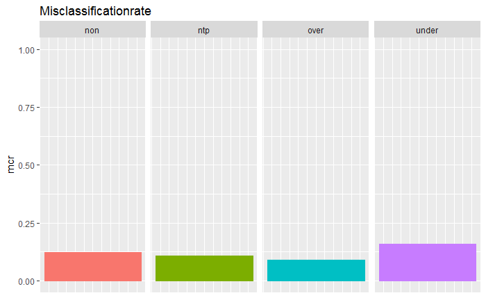

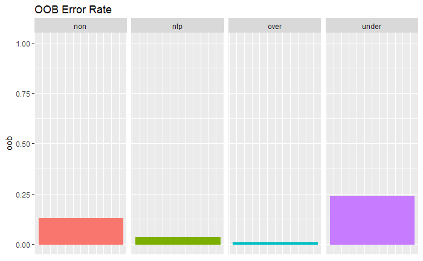

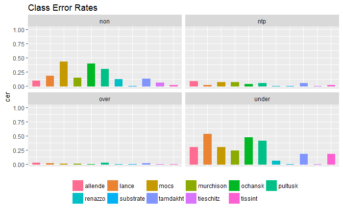

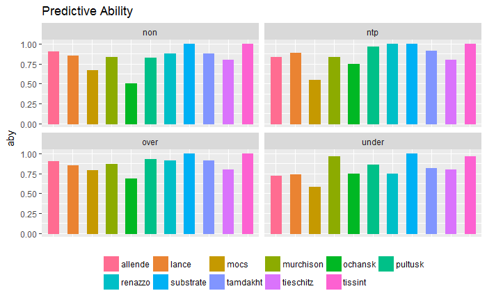

Applying oversampling improves the performance based on the overall error rate (oob error rate). Because the numbers of observations are artificially increased by sampling (from the classes) with replacement the observations that were already classified correctly are almost surely again correctly classified and therefore, the error rate will decrease. The effects of applying same-size sampling (ntp) on the performance of the forest are considered to be quite similar to those of applying oversampling, since more classes have to be blown up and only a few have to be down sized.

So oversampling and same-size sampling cause a decrease of the overall error rate. Undersampling, however, leads to an increase. Since all classes, except the smallest one, have to be down sized one risks the loss of important information, hence the bad performance.

Regarding the class error rates (cer), it’s conspicuous how balancing effects those especially when applying oversampling and same-size sampling (ntp). The class error rates are more evenly distributed and are related to the overall error rate (oob), so they reflect the overall error rate as well as the overall error rate reflects them, which is a very desirable characteristic when it comes to multiple-class classification. Undersampling performs not that well. The extremely good performance of oversampling, however, has to be observed with caution. Be aware that oversampling in this case means that every class has now $240$ observations (the class *substrate* contains $240$ observations). This is almost ten times as many data points as the smallest class contains (the meteorite-class *tieschitz* contains $27$ observations). This might increase the danger of overfitting, or it might not be appropriate at all for some cases, because one changes the prior probabilities of certain classes, which may not be wanted.

Regarding the misclassification rate (mcr), which is based on the test data set, it is interesting to see that the affects of balancing are not that drastic, not that obvious compared to those on the training data. Applying oversampling or same-size sampling (ntp) the misclassification rate stays more or less the same. Only applying undersampling seems to cause an increase, which relates to the effects on the overall error rate and the class error rate based on the training data set. So looking at the misclassification rate balancing the data at least doesn’t worsen the situation.

Although at first glance these effects may not be good, comparing the misclassification rates and the predictive abilities it shows that the misclassification rate in each case relates to the predictive abilities, which is very important, since the misclassification rate should represent the class error rates.

So it seems that oversampling and in this case also same-size sampling might lead to overfitting, but overall spoken it improves the performance of the classification itself and improves it for the test data set although these effects are not that obvious as for the training data set. Undersampling, however, performs very poorly.

## Conclusion

Regarding the *comecs* data set it can be concluded that oversampling leads to the best results with respect to the training data as well as to the test data. The class error rates of the training data are much lower and also the predictive abilities for the independent test data improve. This holds for almost every version of classification that has been done. The main problem of imbalance, being that the class error rates are so to say also unbalanced and not reflected in the overall error rate, can be overcome very effectively by oversampling and also same-size sampling. Same-size sampling is almost as good as oversampling sometimes even better in terms of the effects of balancing. This and the tendency of oversampling to cause overfitting lead to the conclusion that same-size sampling may be the most appropriate balancing method for this classification problem. Also, it takes less computing time than oversampling.

Dealing with unbalanced multiple-class classification in general is a hard task. The purpose of the classification, the importance of the multiple classes and the effects of different balancing methods are different for every data set. Balancing methods that are based on a method of random subsampling seem to be more reasonable for multiple-class problems than cost-sensitive learning, which seems to be more suitable for binary classifications.